# HWell

## Supply chain and analytics

- Story telling using data
- Driving decisions based on design

### Packages:

```python
import pandas as pd
import numpy as np
from numpy import sqrt
from functools import reduce
import matplotlib.pyplot as plt
%matplotlib inline
from sklearn.metrics import mean_squared_error,mean_absolute_error,r2_score
plt.figure(figsize=(40,40))

font = {'family': 'serif','color':  'darkred','weight': 'normal','size': 12,}
# plt.figure(figsize=(40,40))
# plt.style.use('seaborn-bright')
import seaborn as sns
sns.set_context("poster")


params = {'legend.fontsize': 10,
          'legend.handlelength': 2}
plt.rcParams.update(params)
```

### UDF's:

```python
def mean_error(actual,predicted):
    error=actual-predicted
    return error.mean()

def results(data):
    print('RMSE:',sqrt(mean_squared_error(data.Actuals,data.Predictions)))
    print('MEAN_ERROR:',mean_error(data.Actuals,data.Predictions))
    print('MEAN_ABSOLUTE_ERROR:',mean_absolute_error(data.Actuals,data.Predictions))
    print('Corelation Between "Actual_Sales" and "Predicted_Sales":',data['Actuals'].corr(data['Predictions']))

def MAPE(actual,predicted):
    mape = ((predicted - actual)/actual)*100
    return mape
```

### Reading Data:

```python
fileName = "Demand_Analytic_Exercise.xlsx"
data = pd.read_excel(fileName)
```

### Data Preparation:

```python
data = data[2:].reset_index().drop(["index"],axis=1)## Deleting Unwanter rows
```

```python
data.columns = ["Product_Line","Material_ID","Predictions","Actuals"]# Renaming Columns
data = data.loc[~pd.isnull(data.Product_Line),] # Removing Nulls
```

```python
data.isnull().sum()
```

```
Product_Line    0
Material_ID     0
Predictions     0
Actuals         0
dtype: int64
```

```python
data.Actuals = data.Actuals.astype("float64")# Chaning Datatypes
data.Predictions = data.Predictions.astype("float64")
```

```python
data['Error'] = data.Actuals - data.Predictions #Dervied variables
data["ABS"]  = data['Error']/data['Actuals']
```

```python
data.head(10)# Data Preview
```

|  | Product_Line | Material_ID | Predictions | Actuals | Error | ABS |
| --- | --- | --- | --- | --- | --- | --- |
| 0 | Adressable Voice Alarm | 1100-0456 | 118.110236 | 101.574803 | -16.535433 | -0.162791 |
| 1 | Adressable Voice Alarm | 1100-1323 | 0.000000 | 0.787402 | 0.787402 | 1.000000 |
| 2 | Adressable Voice Alarm | 1100-1324 | 0.000000 | 3.149606 | 3.149606 | 1.000000 |
| 3 | Adressable Voice Alarm | DVC-EM | 282.677165 | 192.913386 | -89.763780 | -0.465306 |
| 4 | Adressable Voice Alarm | DVC-KD | 200.787402 | 234.645669 | 33.858268 | 0.144295 |
| 5 | Adressable Voice Alarm | SKE-450 | 24.409449 | 25.196850 | 0.787402 | 0.031250 |
| 6 | Ancilliaries and Control | 1100-0399 | 170.078740 | 103.937008 | -66.141732 | -0.636364 |
| 7 | Automatic Detection | SD505-DUCTR | 218.897638 | 189.763780 | -29.133858 | -0.153527 |
| 8 | Automatic Detection | SD505-HEAT | 414.960630 | 735.433071 | 320.472441 | 0.435760 |
| 9 | Automatic Detection | SD505-PHOTO | 4198.425197 | 3946.456693 | -251.968504 | -0.063847 |

```python
data.tail(10)
```

|  | Product_Line | Material_ID | Predictions | Actuals | Error | ABS |
| --- | --- | --- | --- | --- | --- | --- |
| 190 | Manual Detection | NOT-BG12LX | 1782.677165 | 1485.039370 | -297.637795 | -0.200424 |
| 191 | Manual Detection | SD500-PS | 602.362205 | 990.551181 | 388.188976 | 0.391892 |
| 192 | Manual Detection | SD500-PSDA | 321.259843 | 440.157480 | 118.897638 | 0.270125 |
| 193 | Miscellaneous | FM998 | 744.881890 | 724.409449 | -20.472441 | -0.028261 |
| 194 | Municipal Box | 2450-0028 | 0.000000 | 0.000000 | 0.000000 | NaN |
| 195 | PC Hardware | ONYXWORKS | 21.259843 | 17.322835 | -3.937008 | -0.227273 |
| 196 | TPPL | ACPS-610 | 216.535433 | 292.125984 | 75.590551 | 0.258760 |
| 197 | TPPL | AMPS-24 | 302.362205 | 289.763780 | -12.598425 | -0.043478 |
| 198 | TPPL | APS2-6R | 94.488189 | 89.763780 | -4.724409 | -0.052632 |
| 199 | TPPL | FCPS-24FS6 | 643.307087 | 737.007874 | 93.700787 | 0.127137 |

### Error Distribution:

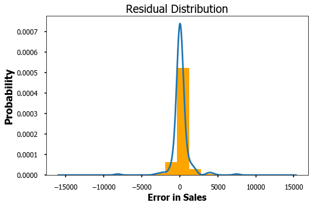

```python
fig, ax = plt.subplots()
data.Error.plot.kde(ax=ax, legend=False, title='Residual Distribution')
data.Error.plot.hist(density=True, ax=ax,color="orange")
ax.set_ylabel('Probability',fontweight="bold")
plt.xlabel("Error in Sales",size=15,fontweight='bold')
plt.xticks(size=12)
plt.yticks(size=12)
plt.show()
```

### Target Distribution:

###### Actuals Sales:

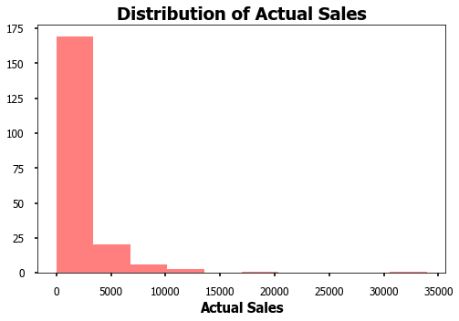

```python
plt.rcParams["figure.figsize"] = (8,5)

plt.hist(data.Actuals, alpha=0.5,color='red')
#plt.hist(data.Predictions,alpha=0.3,color='green')
plt.title("Distribution of Actual Sales",size=20,fontweight='bold')
plt.xlabel("Actual Sales",size=15,fontweight='bold')
plt.xticks(size=12)
plt.yticks(size=12)
# plt.legend()
plt.show()
```

###### Predicted Sales:

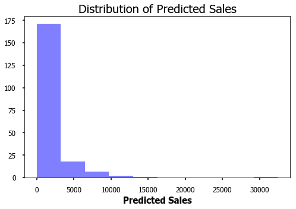

```python
plt.hist(data.Predictions, alpha=0.5,color='blue')
#plt.hist(data.Predictions,alpha=0.3,color='green')
plt.title("Distribution of Predicted Sales",size=20)
plt.xlabel("Predicted Sales",size=15,fontweight='bold')
plt.xticks(size=12)
plt.yticks(size=12)
# plt.legend()
plt.show()
```

- As Distribution is more or simillar same we can say that forecasted results are good!

### Data Exploration & Performance Assesment:

## Exploratary Data Analysis:

- Difference and % between forecast and actuals
- Total error and absolute error
- MAPE (abs. error/actuals)
- Ranking by Product Line sub-totals
- Bias (tendency to forecast high or low)
- Sub-totals by-product line
- Grand Totals

### No. of Materials in each Product Line

```python
print("Total Product Lines present:",data.Product_Line.nunique())# validations
```

```
Total Product Lines present: 15
```

```python
data.Product_Line.value_counts()
```

```
Automatic Detection          75
Control Panels               63
Manual Detection             14
AV Devices                   13
Loudspeakers                  8
Adressable Voice Alarm        6
Energy Supply                 6
Distributed Systems           5
TPPL                          4
Field Interfaces              1
PC Hardware                   1
Ancilliaries and Control      1
Miscellaneous                 1
Municipal Box                 1
Fire Sprinkler Monitoring     1
Name: Product_Line, dtype: int64
```

### Material Count by Product Line:

```python
material_count = pd.DataFrame(data.Product_Line.value_counts()).reset_index().rename(columns={"index":"Product_Line","Product_Line":"Count"})
material_count
```

|  | Product_Line | Count |
| --- | --- | --- |
| 0 | Automatic Detection | 75 |
| 1 | Control Panels | 63 |
| 2 | Manual Detection | 14 |
| 3 | AV Devices | 13 |
| 4 | Loudspeakers | 8 |
| 5 | Adressable Voice Alarm | 6 |
| 6 | Energy Supply | 6 |
| 7 | Distributed Systems | 5 |
| 8 | TPPL | 4 |
| 9 | Field Interfaces | 1 |
| 10 | PC Hardware | 1 |
| 11 | Ancilliaries and Control | 1 |
| 12 | Miscellaneous | 1 |
| 13 | Municipal Box | 1 |
| 14 | Fire Sprinkler Monitoring | 1 |

#### Visual Representaiton:

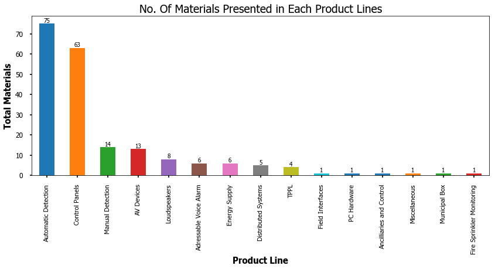

```python
plt.rcParams["figure.figsize"] = (14,5)
data.Product_Line.value_counts().plot(kind='bar')
plt.title("No. Of Materials Presented in Each Product Lines")
plt.xlabel("Product Line",size=15,fontweight='bold')
plt.xticks(size=11,rotation=90)
plt.yticks(size=9)
plt.yticks(size=12)
plt.ylabel("Total Materials",size=15,fontweight='bold')
# plt.text(list(data.Product_Line.value_counts().values))
# plt.legend(loc = "best","Total")
for x,y in zip(np.arange(15),material_count.Count):
    plt.text(x, y+0.05, '%.0f' % y, ha='center', va= 'bottom',size=10)
plt.show()
```

##### Calculating Descriptive statistics to asses model Performance:

```python
data.Error.describe()
```

```
count     200.000000
mean      114.940945
std      1109.482486
min     -8174.015748
25%       -66.732283
50%         0.787402
75%       252.559055
max      7469.291339
Name: Error, dtype: float64
```

```python
df = pd.merge(data.groupby(['Product_Line'])[['Actuals']].sum().reset_index(),data.groupby(['Product_Line'])[['Predictions']].sum().reset_index(),on="Product_Line").sort_values(["Actuals",'Predictions'],ascending=False)
```

### Ranking Of Product Line Items by their Sales Subtotals

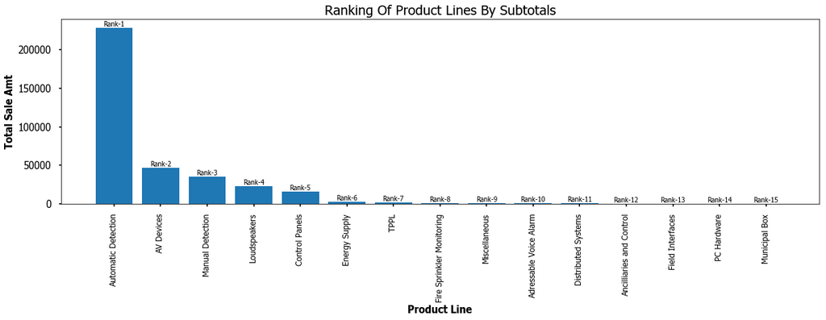

```python
plt.rcParams["figure.figsize"] = (20,5)
plt.bar(df.Product_Line,df.Actuals)
plt.title("Ranking Of Product Lines By Subtotals",size=20)
plt.xlabel("Product Line",size=15,fontweight='bold')
plt.ylabel("Total Sale Amt",size=15,fontweight='bold')
plt.xticks(size=12,rotation=90)
plt.yticks(size=15)



for x,y in zip(np.arange(15),df.Actuals):
    plt.text(x, y+0.05, "Rank-{}".format(x+1), ha='center', va= 'bottom',size=10)
plt.show()
```

- Above Plot showing that **Rank** of Product Lines as per total sales happend during the period for a particular product Line item.
- Product Line **Automatic Detection** category were saled high followed by **AV Devices**. But **Automatic Detection** has **75**. So materials. So it has been justified as it contains high materials obvioulsy high sales happend for this Product Line.
- But **AV Devices** stood in **2nd rank** but total materials presented are **13**.

#### Error Analysis:

- Sortation by error: in total, by product line
- Cumulative contribution to error, by product line and in total

```python
avg_preds = data.groupby(['Product_Line'])[['Predictions']].mean().reset_index()
avg_actuals = data.groupby(['Product_Line'])[['Actuals']].mean().reset_index()
sd_preds =data.groupby(['Product_Line'])[['Predictions']].std().reset_index()
sd_actuals =data.groupby(['Product_Line'])[['Actuals']].std().reset_index()
```

```python
avg_sd = reduce(lambda left,right: pd.merge(left,right,on='Product_Line'), [avg_preds,avg_actuals,sd_preds,sd_actuals,tot_mats]).rename(columns={"Predictions_x":"Predictions_Avg","Predictions_y":"Predictions_SD","Actuals_x":"Actuals_Avg","Actuals_y":"Actuals_SD"})
avg_sd.fillna(0,inplace=True)
```

```python
avg_sd['Error_Mean'] = avg_sd.Actuals_Avg - avg_sd.Predictions_Avg
avg_sd['Error_SD'] = avg_sd.Actuals_SD - avg_sd.Predictions_SD
avg_sd.sort_values(['Error_Mean','Error_SD']).reset_index().drop(['index'],axis=1)
avg_sd = avg_sd.sort_values(['Predictions_Avg','Actuals_Avg'],ascending=False)
avg_sd.reset_index().drop(['index'],axis=1)
```

|  | Product_Line | Predictions_Avg | Actuals_Avg | Predictions_SD | Actuals_SD | Total_Materials | Error_Mean | Error_SD |
| --- | --- | --- | --- | --- | --- | --- | --- | --- |
| 0 | Loudspeakers | 4648.326772 | 2888.976378 | 4002.969676 | 1849.706643 | 8 | -1759.350394 | -2153.263033 |
| 1 | AV Devices | 3788.612962 | 3597.637795 | 2575.817755 | 2437.072536 | 13 | -190.975167 | -138.745219 |
| 2 | Automatic Detection | 2631.538058 | 3046.152231 | 4405.044358 | 4850.703224 | 75 | 414.614173 | 445.658866 |
| 3 | Manual Detection | 2102.474691 | 2539.651294 | 2366.196241 | 2460.939031 | 14 | 437.176603 | 94.742789 |
| 4 | Fire Sprinkler Monitoring | 799.212598 | 1200.787402 | 0.000000 | 0.000000 | 1 | 401.574803 | 0.000000 |
| 5 | Miscellaneous | 744.881890 | 724.409449 | 0.000000 | 0.000000 | 1 | -20.472441 | 0.000000 |
| 6 | Energy Supply | 317.060367 | 461.417323 | 312.929144 | 496.965309 | 6 | 144.356955 | 184.036165 |
| 7 | TPPL | 314.173228 | 352.165354 | 235.416831 | 273.530641 | 4 | 37.992126 | 38.113810 |
| 8 | Control Panels | 233.195851 | 250.806149 | 305.535220 | 317.054882 | 63 | 17.610299 | 11.519662 |
| 9 | Ancilliaries and Control | 170.078740 | 103.937008 | 0.000000 | 0.000000 | 1 | -66.141732 | 0.000000 |
| 10 | Adressable Voice Alarm | 104.330709 | 93.044619 | 117.862996 | 101.284964 | 6 | -11.286089 | -16.578032 |
| 11 | Distributed Systems | 104.094488 | 97.322835 | 51.589527 | 51.267643 | 5 | -6.771654 | -0.321884 |
| 12 | Field Interfaces | 92.913386 | 85.039370 | 0.000000 | 0.000000 | 1 | -7.874016 | 0.000000 |
| 13 | PC Hardware | 21.259843 | 17.322835 | 0.000000 | 0.000000 | 1 | -3.937008 | 0.000000 |
| 14 | Municipal Box | 0.000000 | 0.000000 | 0.000000 | 0.000000 | 1 | 0.000000 | 0.000000 |

### Error Visulaization:

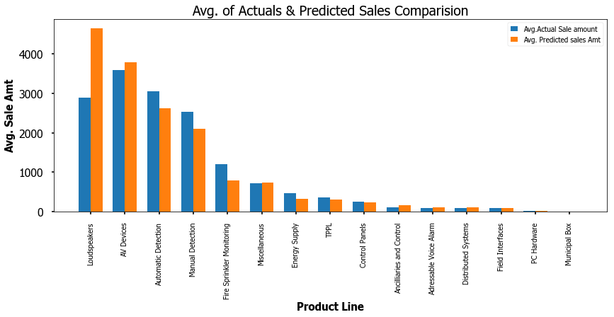

```python
ind = np.arange(avg_sd.shape[0])
width = 0.35
plt.bar(ind, avg_sd.Actuals_Avg, width, label='Avg.Actual Sale amount')
plt.bar(ind + width, avg_sd.Predictions_Avg, width,label='Avg. Predicted sales Amt')

# plt.bar(ind, -avg_sd.Actuals_SD, width, label='Avg.Actual Sale amount')
# plt.bar(ind + width, -avg_sd.Predictions_SD, width,label='Avg. Predicted sales Amt')

plt.xlabel("Product Line",size=15,fontweight='bold')
plt.ylabel("Avg. Sale Amt",size=15,fontweight='bold')
plt.title('Avg. of Actuals & Predicted Sales Comparision')
plt.xticks(ind + width / 2, (avg_sd.Product_Line),rotation=90,size=10)
plt.legend(loc='best')
plt.show()
```

- From Above plot we can conclude that some produce Line items predicted **more** amount than actual called (*POSTIVE EFFECT*) & Some are predicted **less** amount(*NEGATIVE EFFECT*) compared to actual.
- Top **Product Line** categories fall in **Positve Effect** are:
  - Loudspeakers
  - AV Devices
- Top **Product Line** categories fall in **Negative Effect** are:
  - Fire Sprinkler Monitoring
  - Automatic Detection
  - Manual Detections

### Varience of Error for all product Lines:

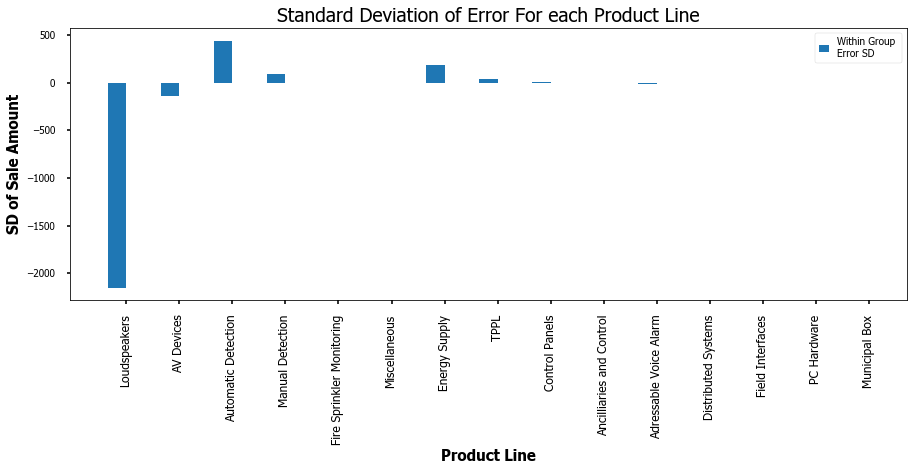

```python
plt.bar(ind, avg_sd.Error_SD, width, label='Within Group \nError SD')

plt.xlabel("Product Line",size=15,fontweight='bold')
plt.ylabel("SD of Sale Amount",size=15,fontweight='bold')
plt.title('Standard Deviation of Error For each Product Line')
plt.xticks(ind + width / 2, (avg_sd.Product_Line),rotation=90,size=12)
plt.yticks(size=10)
plt.legend(loc='best')
plt.show()
```

- **Postive Direction** means Predicted sale amount is **Less** compared to actual sale amount.
- **Negative Direction** means Predicted sale amount is **More** compared to actual sale amount.

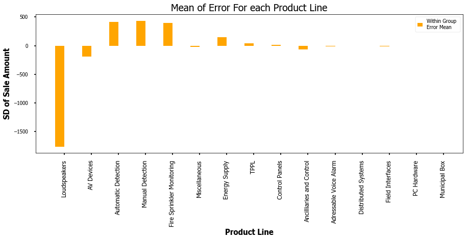

```python
plt.bar(ind, avg_sd.Error_Mean, width, label='Within Group \nError Mean',color='orange')

plt.xlabel("Product Line",size=15,fontweight='bold')
plt.ylabel("SD of Sale Amount",size=15,fontweight='bold')
plt.title('Mean of Error For each Product Line')
plt.xticks(ind + width / 2, (avg_sd.Product_Line),rotation=90,size=12)
plt.yticks(size=10)
plt.legend(loc='best')
plt.show()
```

## Predictions Vs Actual sales Variation:

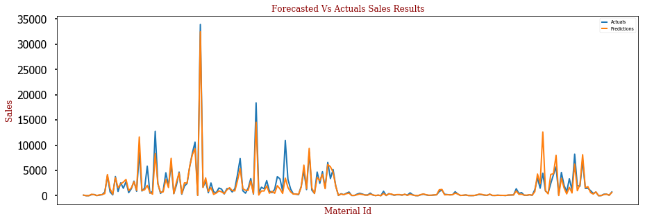

```python
plt.rcParams["figure.figsize"] = (15,5)
plt.plot(data.index,data.Actuals,lw=2)
plt.plot(data.index,data.Predictions,lw=2)
plt.title("Forecasted Vs Actuals Sales Results",fontdict=font)
plt.xlabel("Material Id",fontdict=font)
plt.ylabel("Sales",fontdict=font)
plt.legend(fontsize="x-small")
plt.tick_params(axis='x', which='both',bottom=False, top=False, labelbottom=False)
plt.show()
```

- Above Plot depicts just that variation of **Actual sales** and **Forecasted sales** for all materials presented. Generally to see if any pattern based on time series like **Trend, seasonality**..etc . But here as we have only one month of data this is enough. Predictions are pretty good!

## Conclusion

### Performance metrics:

```python
results(data)
```

```
RMSE: 1112.6581014472063
MEAN_ERROR: 114.94094488188978
MEAN_ABSOLUTE_ERROR: 480.0275590551181
Corelation Between "Actual_Sales" and "Predicted_Sales": 0.9456208744812649
```

### Final Results:

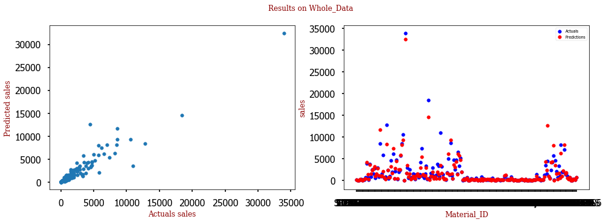

```python
plt.rcParams["figure.figsize"] = (16,5)
Title = "Results on Whole_Data"
fig, (ax1,ax2) = plt.subplots(1,2)
fig.suptitle(Title,fontdict=font)
ax1.scatter(data.Actuals,data.Predictions,s=30)
ax1.set_xlabel("Actuals sales",fontdict=font)
ax1.set_ylabel("Predicted sales",fontdict=font)

ax2.scatter(data.Material_ID,data.Actuals,s=30, c='b', marker="o", label='Actuals')
ax2.scatter(data['Material_ID'], data.Predictions,s=30, c='r', marker="o", label='Predictions')
ax2.set_xlabel("Material_ID",fontdict=font)
ax2.set_ylabel("sales",fontdict=font)
ax2.legend(fontsize="x-small")
```

- Above Plots Showing that Actual Sales and Predicted Sales and the **Colinear relation** between them.
- Left plot giving that almost linear relationship between forecasted and actuals sales. Its about **95%** has proven from descriptive stats called **Correlation** measure.
- Right Plot showing for each and every materials how forecaseted values scatterd around.